# Election Outcome Estimates

APCA

8/27/2021

# Estimating Election Outcomes for Proposed Districts

- Using the 2020 geographies means that the voting data is not yet appended to my Maptitude base layer. I’ll estimate these indicators for proposed districts using a simple block centroid spatial join. These will be estimates, not the official data (which will be released by SWDB around Sept 20).

### Sketch 6 Summary

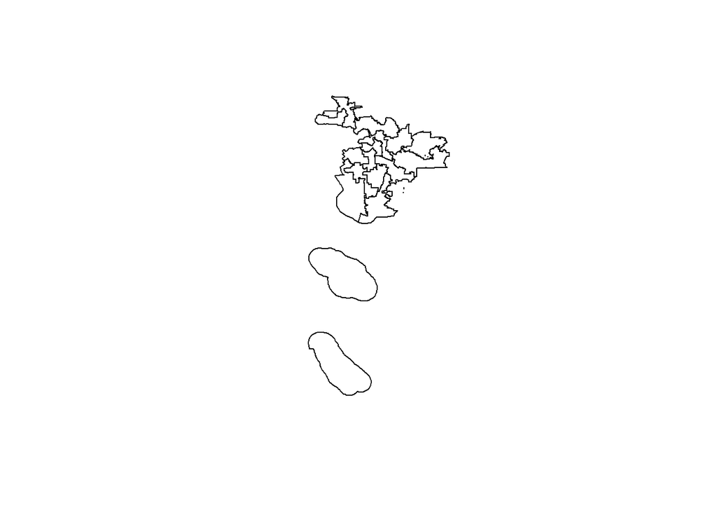

- 2020 proposition outcomes (percent of voters who approve the proposition) with the share of the Latinx and Asian vote and the registered voter turnout (RVT) in the 2020 General Election.

| DISTRICT | prc_p15 | prc_p16 | prc_p17 | prc_p21 | prc_latvote | prc_asnvote | lat_rvt | asn_rvt |
| --- | --- | --- | --- | --- | --- | --- | --- | --- |
| 39 | 51.88% | 48.76% | 62.87% | 50.45% | 49.04% | 5.61% | 69.08% | 73.37% |
| 42 | 51.65% | 48.14% | 62.45% | 48.36% | 18.27% | 9.41% | 76.40% | 78.87% |
| 46 | 53.11% | 48.92% | 62.88% | 52.37% | 46.02% | 8.54% | 67.72% | 72.13% |
| V09 | 46.92% | 39.63% | 52.43% | 39.65% | 29.02% | 39.52% | 74.25% | 71.50% |
| V10 | 47.79% | 42.91% | 55.34% | 42.57% | 59.08% | 12.25% | 72.35% | 71.87% |
| V11 | 43.70% | 40.03% | 52.03% | 38.45% | 51.89% | 17.56% | 75.79% | 75.15% |
| V12 | 65.14% | 59.74% | 71.04% | 63.02% | 47.18% | 16.22% | 66.06% | 65.46% |
| V13 | 65.29% | 62.22% | 74.69% | 62.52% | 43.88% | 7.61% | 69.34% | 75.95% |
| V14 | 63.12% | 61.69% | 76.49% | 57.65% | 49.30% | 4.85% | 59.69% | 62.34% |
| V15 | 61.22% | 64.59% | 78.41% | 56.54% | 22.12% | 6.56% | 69.19% | 77.19% |
| V16 | 57.04% | 58.40% | 74.33% | 52.88% | 56.19% | 2.27% | 63.01% | 63.51% |
| V17 | 54.99% | 51.23% | 67.49% | 51.95% | 44.54% | 6.32% | 64.10% | 66.87% |
| V24 | 49.14% | 45.07% | 58.13% | 45.11% | 63.52% | 6.03% | 70.68% | 73.29% |
| V25 | 55.28% | 56.25% | 70.42% | 52.49% | 37.11% | 9.25% | 68.15% | 71.59% |
| V26 | 41.77% | 38.00% | 54.42% | 35.05% | 12.33% | 13.62% | 77.84% | 81.51% |

### Sketch 7 Summary

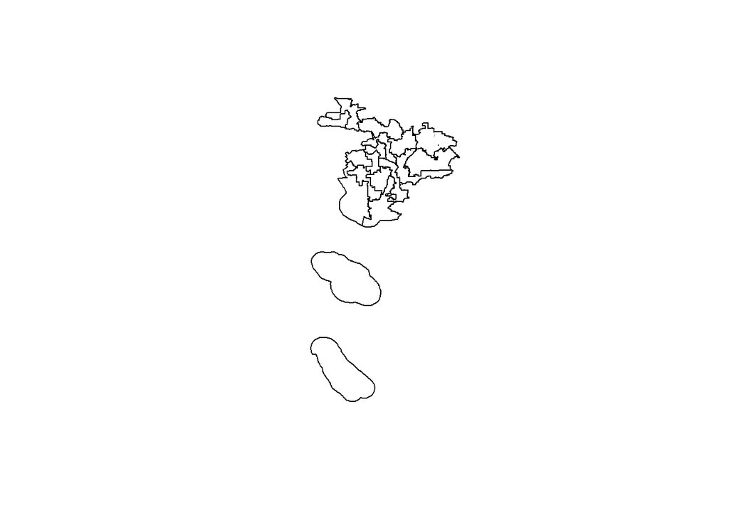

- 2020 proposition outcomes (percent of voters who approve the proposition) with the share of the Latinx and Asian vote and the registered voter turnout (RVT) in the 2020 General Election.

| DISTRICT | prc_p15 | prc_p16 | prc_p17 | prc_p21 | prc_latvote | prc_asnvote | lat_rvt | asn_rvt |
| --- | --- | --- | --- | --- | --- | --- | --- | --- |
| NEWVRA | 47.43% | 43.81% | 56.71% | 43.12% | 65.40% | 8.23% | 73.38% | 73.55% |
| V09 | 46.93% | 39.63% | 52.44% | 39.66% | 29.03% | 39.54% | 74.25% | 71.49% |
| V10 | 43.72% | 39.22% | 51.92% | 38.95% | 48.05% | 11.42% | 74.64% | 74.39% |
| V11 | 43.85% | 39.56% | 51.50% | 38.06% | 49.12% | 18.89% | 74.97% | 74.56% |
| V12 | 65.14% | 59.74% | 71.04% | 63.02% | 47.18% | 16.22% | 66.06% | 65.46% |
| V13 | 65.29% | 62.22% | 74.69% | 62.52% | 43.88% | 7.61% | 69.34% | 75.95% |
| V14 | 63.12% | 61.69% | 76.49% | 57.65% | 49.30% | 4.85% | 59.69% | 62.34% |
| V15 | 61.22% | 64.59% | 78.41% | 56.54% | 22.12% | 6.56% | 69.19% | 77.19% |
| V16 | 57.04% | 58.40% | 74.33% | 52.88% | 56.19% | 2.27% | 63.01% | 63.51% |
| V17 | 54.96% | 51.16% | 67.46% | 51.92% | 44.64% | 6.25% | 64.16% | 67.17% |
| V20 | 51.86% | 48.73% | 62.85% | 50.44% | 49.03% | 5.62% | 69.09% | 73.37% |
| V21 | 53.10% | 48.90% | 62.87% | 52.36% | 46.00% | 8.54% | 67.72% | 72.14% |
| V24 | 47.19% | 43.71% | 57.83% | 42.89% | 45.21% | 5.84% | 70.42% | 74.47% |
| V25 | 55.28% | 56.25% | 70.42% | 52.49% | 37.11% | 9.25% | 68.15% | 71.59% |
| V26 | 41.77% | 38.00% | 54.42% | 35.05% | 12.33% | 13.62% | 77.84% | 81.51% |
| V29 | 51.30% | 47.84% | 62.04% | 47.91% | 18.61% | 9.66% | 76.21% | 78.70% |

### Sketch 6 with Revised SFV Summary

- Based on Sketch 6 with revised San Fernando Valley

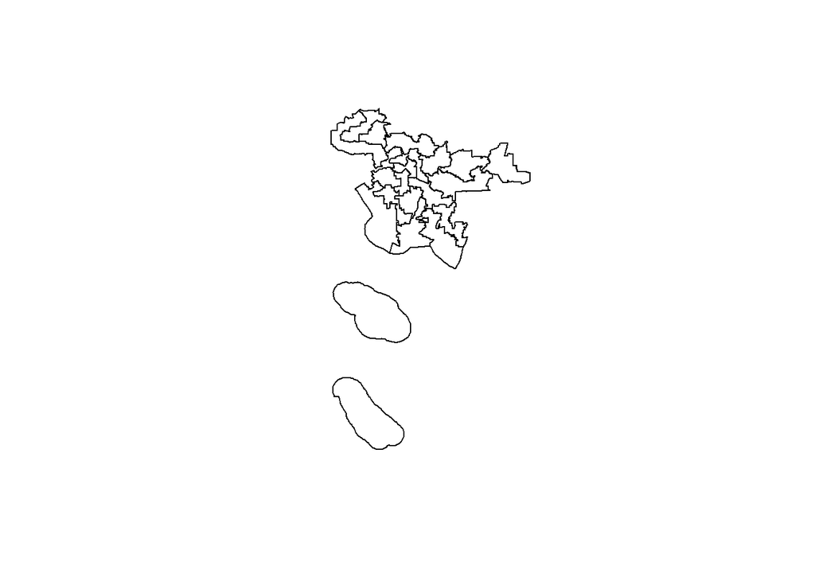

- 2020 proposition outcomes (percent of voters who approve the proposition) with the share of the Latinx and Asian vote and the registered voter turnout (RVT) in the 2020 General Election.

| DISTRICT | prc_p15 | prc_p16 | prc_p17 | prc_p21 | prc_latvote | prc_asnvote | lat_rvt | asn_rvt |
| --- | --- | --- | --- | --- | --- | --- | --- | --- |
| 39 | 49.62% | 46.58% | 60.45% | 47.89% | 46.02% | 8.23% | 70.17% | 72.67% |
| 42 | 51.56% | 48.05% | 62.37% | 48.25% | 18.19% | 9.44% | 76.46% | 78.87% |
| 43 | 65.29% | 62.23% | 74.70% | 62.52% | 43.86% | 7.61% | 69.34% | 75.95% |
| 44 | 46.27% | 43.68% | 59.42% | 42.97% | 11.00% | 7.25% | 77.50% | 78.80% |
| 46 | 55.72% | 51.40% | 65.70% | 55.35% | 47.70% | 5.55% | 67.09% | 72.90% |
| 48 | 47.79% | 42.91% | 55.35% | 42.57% | 59.10% | 12.24% | 72.35% | 71.87% |
| 49 | 46.91% | 39.64% | 52.43% | 39.65% | 29.05% | 39.46% | 74.25% | 71.50% |
| 51 | 65.14% | 59.74% | 71.04% | 63.02% | 47.18% | 16.22% | 66.06% | 65.46% |
| 52 | 47.86% | 42.84% | 57.96% | 41.83% | 42.50% | 8.02% | 68.61% | 73.65% |
| 54 | 61.29% | 64.43% | 78.27% | 56.68% | 21.72% | 6.62% | 69.32% | 77.12% |
| 57 | 43.95% | 40.45% | 56.39% | 38.56% | 21.41% | 6.36% | 78.20% | 78.15% |
| 59 | 63.12% | 61.69% | 76.49% | 57.65% | 49.30% | 4.85% | 59.69% | 62.34% |
| 60 | 49.14% | 45.07% | 58.13% | 45.11% | 63.51% | 6.03% | 70.68% | 73.30% |
| 62 | 55.28% | 56.27% | 70.43% | 52.50% | 37.13% | 9.25% | 68.15% | 71.59% |
| 63 | 43.70% | 40.03% | 52.03% | 38.46% | 51.88% | 17.56% | 75.79% | 75.15% |
| 64 | 57.04% | 58.40% | 74.32% | 52.88% | 56.20% | 2.27% | 63.01% | 63.51% |
| 66 | 41.77% | 38.00% | 54.42% | 35.06% | 12.33% | 13.62% | 77.84% | 81.51% |
| 70 | 54.94% | 51.19% | 67.47% | 51.82% | 44.01% | 6.44% | 64.17% | 67.21% |
| 72 | 42.83% | 39.83% | 49.40% | 35.58% | 20.82% | 36.13% | 77.42% | 76.67% |

### Sketch 7 with Revised SFV Summary

- Based on Sketch 7 with revised San Fernando Valley

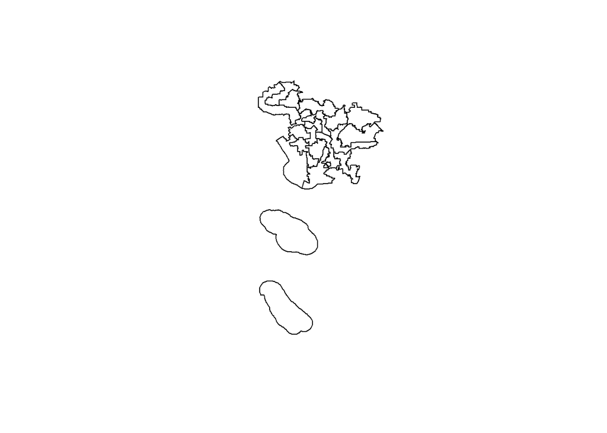

- 2020 proposition outcomes (percent of voters who approve the proposition) with the share of the Latinx and Asian vote and the registered voter turnout (RVT) in the 2020 General Election.

| DISTRICT | prc_p15 | prc_p16 | prc_p17 | prc_p21 | prc_latvote | prc_asnvote | lat_rvt | asn_rvt |
| --- | --- | --- | --- | --- | --- | --- | --- | --- |
| 39 | 49.62% | 46.58% | 60.45% | 47.89% | 46.02% | 8.23% | 70.17% | 72.67% |
| 40 | 43.72% | 39.22% | 51.92% | 38.95% | 48.05% | 11.42% | 74.64% | 74.39% |
| 42 | 51.56% | 48.05% | 62.37% | 48.25% | 18.19% | 9.44% | 76.46% | 78.87% |
| 43 | 65.29% | 62.23% | 74.70% | 62.52% | 43.86% | 7.61% | 69.34% | 75.95% |
| 44 | 46.27% | 43.68% | 59.42% | 42.97% | 11.00% | 7.25% | 77.50% | 78.80% |
| 46 | 55.72% | 51.40% | 65.70% | 55.35% | 47.70% | 5.55% | 67.09% | 72.90% |
| 48 | 43.85% | 39.56% | 51.50% | 38.06% | 49.12% | 18.89% | 74.97% | 74.56% |
| 49 | 46.92% | 39.63% | 52.43% | 39.65% | 29.02% | 39.52% | 74.26% | 71.50% |
| 51 | 65.14% | 59.74% | 71.04% | 63.02% | 47.18% | 16.22% | 66.06% | 65.46% |
| 54 | 61.29% | 64.43% | 78.27% | 56.68% | 21.72% | 6.62% | 69.32% | 77.12% |
| 59 | 63.12% | 61.69% | 76.49% | 57.65% | 49.30% | 4.85% | 59.69% | 62.34% |
| 60 | 47.19% | 43.71% | 57.83% | 42.89% | 45.21% | 5.84% | 70.42% | 74.48% |
| 62 | 55.28% | 56.27% | 70.43% | 52.50% | 37.13% | 9.25% | 68.15% | 71.59% |
| 63 | 47.43% | 43.81% | 56.71% | 43.12% | 65.40% | 8.23% | 73.38% | 73.55% |
| 64 | 57.04% | 58.40% | 74.32% | 52.88% | 56.20% | 2.27% | 63.01% | 63.51% |
| 66 | 41.77% | 38.00% | 54.42% | 35.06% | 12.33% | 13.62% | 77.84% | 81.51% |
| 70 | 54.96% | 51.16% | 67.46% | 51.92% | 44.64% | 6.25% | 64.16% | 67.17% |
| 72 | 42.83% | 39.83% | 49.40% | 35.58% | 20.82% | 36.13% | 77.42% | 76.67% |